# Central Limit Theorem

Applied Statistics

MTH-361A | Spring 2026 | University of Portland

# Objectives

- **Introduce the Central Limit Theorem (CLT)**
- **Develop an understanding how CLT works**
- **Develop an understanding why CLT matters in inference**

# The Central Limit Theorem (CLT)

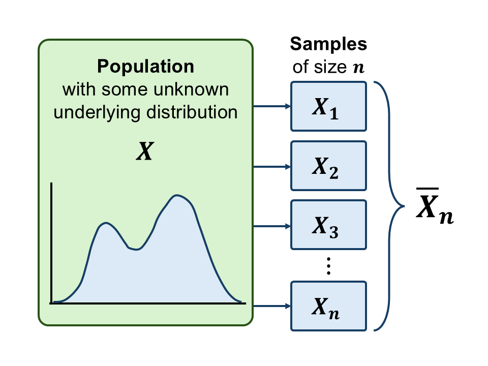

**Definition:**

- Let $X_1,X_2, \cdots X_n$ be i.i.d. r.v.s, which denote a statistical sample of size $n$ from a population distribution with finite positive variance.
- Let $\overline{X}_n$ a statistical measurement (i.e. sample mean), which is itself an r.v..
- The limit as $n \to \infty$ of the distribution of $\overline{X}_n$ is a normal distribution.

$\star$ The probability distribution of $\overline{X}_n$ is called the sampling distribution.

# The Sampling Distribution

**Definition:**

- A probability distribution of a statistic.
- A statistic can be a proportion, mean, median, standard deviation, $\cdots$ etcetera.

**CLT Conditions:**

- **Independence:** Sample values must be independent
- **Identical distribution:** Samples should be from the same distribution with a fixed parameter
- **Finite variance:** The population must have a finite variance
- **Large sample size:** A larger sample size improves approximation

**The Normal Distribution:**

The normal distribution is a type of a sampling distribution as long the CLT conditions hold.

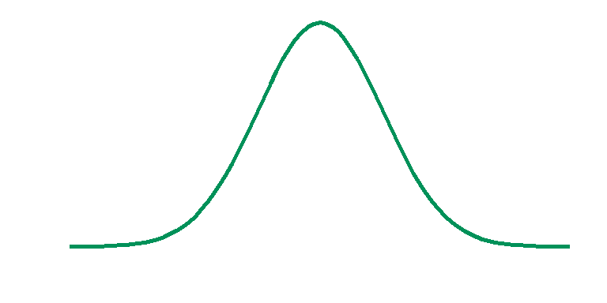

$\star$ With a sufficiently large sample size, the mean of the sampling distribution is approximately equal to the corresponding parameter of the underlying population.

# The CLT Formula

The CLT is very useful because it tell us that the sampling distribution of the sample mean is normal, regardless of the population’s distribution shape.

**Sampling distribution of the sample mean:**

- For large sample size $n$, the sampling distribution of the sample mean $\overline{X}_n$ is approximately normal.
- Its expected value is the population mean: $\displaystyle \text{E}(\overline{X}_n) = \mu$.
- The variance is by a factor of $\frac{1}{n}$ of the population variance: $\displaystyle \text{Var}(\overline{X}_n) = \frac{\sigma^2}{n}$
- As we increase $n$, the variance $\text{Var}(\overline{X}_n)$ approaches zero, meaning the sample mean $\text{E}(\overline{X}_n)$ approaches $\mu$.

**The CLT z-score:**

Under CLT, $\mu$ is the mean and $\frac{\sigma^2}{n}$ is the variance.

- We standardize the sample mean using the z-score formula:
  $$z = \frac{\overline{x} -
  \mu}{\frac{\sigma}{\sqrt{n}}}$$

$\star$ The sample standard deviation $s$ is used when the population standard deviation $\sigma$ is unknown.

# The Sampling Distribution Under CLT

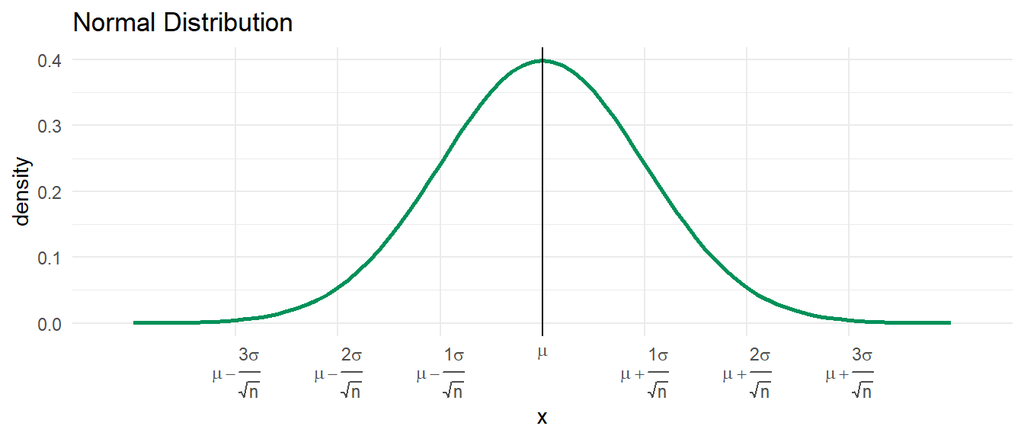

$\star$ The distribution remains the same except that the standard deviations of this normal distribution is multiplied by a factor of $\frac{1}{\sqrt{n}}$.

# Mean Annual Household Income (1/2)

Suppose that we want to estimate the mean annual income of the city of *Fancyland*.

**Data:**

Here, we show a distribution of $140$ annual household incomes. The numbers are in thousands.

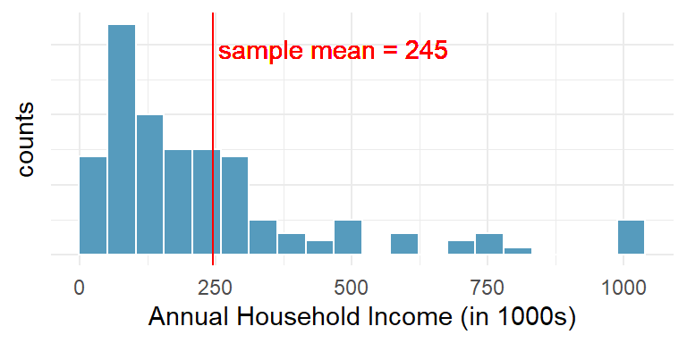

Let $\overline{x} = 245$ be the *estimate*.

$\dagger$ The sample mean $\overline{x}$ is known as an *unbiased estimator* of the population mean $\mu$ because $\text{E}(\overline{X}) = \mu$ over repeated sampling.

**Sampling distribution:**

- Suppose that we *sample $140$ annual incomes again* from the same city and *record the mean annual income* and repeat this *multiple times*.
- The sample means will vary but we can *assume that the sampling distribution of these means is approximately normal*.
- Even though the annual income data are right-skewed, the sampling distribution of the sample mean is approximately normal under the CLT.

$\star$ We can’t take data multiple times due to practical constraints. That is why we assume CLT as long as the conditions hold.

# Mean Annual Household Income (2/2)

Suppose we want to estimate the variance of the sampling distribution of the mean annual income.

**Information from the data:**

- The sample mean is $\overline{x} = 245$.
- The sample standard deviation is $s = 226$.
- The sample size is $n = 140$.

**The unknowns:**

- We don’t know the population mean $\mu$ (true mean annual income).
- We don’t know the population variance $\sigma^2$ (true variance of the annual incomes).

# Parameter Estimation

The mean annual income $\overline{x} = 245$ is an estimate for an unknown parameter, but how good is this estimate?

**Sampling distribution of the observation:**

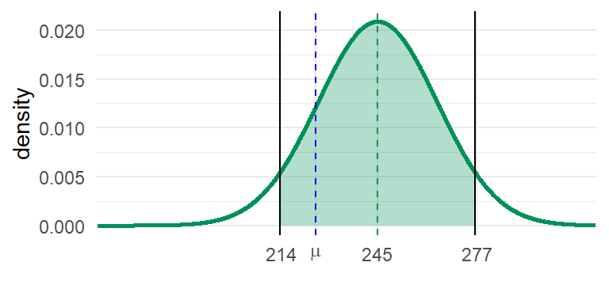

# Hypothesis Testing (1/3)

The mean annual income $\overline{x} = 245$ is an observation from the data, but how far is this observation from a null value?

**Why it matters for hypothesis testing:**

- The null hypothesis is a statement about a population parameter that represents a default assumption, which we assume as true.
- Using CLT, we can compute the probability of observing a sample mean as extreme as $\overline{x} = 245$.
- This probability is called the *p-value*.

**Sampling distribution of the null value:**

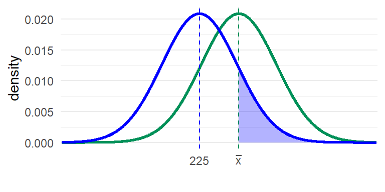

$\star$ The p-value answers the question: If the true mean were $\mu = 225$, how likely is it to observe a sample mean this far (or farther) from $\mu$ just by random chance?

# Hypothesis Testing (2/3)

**The null hypothesis:**

- It states that the population mean is equal to a specified value $\mu = \mu_0$.
- Suppose that the true mean annual income is $\mu_0 = 225$.
- So, $H_0: \mu = 225$.
- In context: Note that we actually don’t know the true mean annual income. We are just assuming prior knowledge that Fancyland is that fancy.

**The alternative hypothesis:**

- Since our observation is $\overline{x} = 245$, we offer an alternative hypothesis (or claim) that the true mean is greater than the null value $\mu_0 = 225$.
- So, $H_A: \mu > 225$.
- In context: We claim that Fancyland is fancier than originally thought.

**The p-value:**

- To compute the p-value you need to assume CLT, meaning all of its conditions are assumed to hold.
- We compute the z-score before computing the p-value, which we call the *test statistic*:
  $$\begin{aligned}
  z & = \frac{\overline{x} - \mu_0}{s / \sqrt{n}}\\
  & = \frac{245 - 225}{226 / \sqrt{140}} \\
  z & \approx 1.047
  \end{aligned}$$
- The p-value is $P(Z \ge z | H_0) = 0.148$, where $Z$ is an r.v. with the standard normal distribution.

**Using R:**

```r
1-pnorm(1.047,0,1)
```

```
## [1] 0.1475498
```

$\star$ Note the conditional probability notation $P(Z \ge z | H_0)$ for the p-value, which is not the same as $P(H_0 | Z \ge z)$.

# Hypothesis Testing (3/3)

**Interpreting the p-value:**

- There is a $0.148$ probability of observing a sample mean at least as large as $\overline{x} = 245$, given the $H_0$ is true.
- Is this enough evidence? There is not a sufficient evidence to support $H_A: \mu > 225$. The p-value is “relatively large”, indicating that the observed result is not unusual under $H_0: \mu = 225$. The observation we obtained likely occurred due to random chance (or sampling variability).
- In context: There is no sufficient evidence to support our claim that Fancyland is fancier than originally thought. The city of Fancyland remains fancy but not too fancy.

$\star$ Deciding whether we have sufficient evidence (to “reject” or “fail to reject” the null hypothesis) requires a *significance level*, a probability that we choose in advance and use to compare with the p-value.